# Introduction

## Dataset: Titanic

### The following Data Analysis has been divided into 6 parts.

1. Feature Engineering
2. Missing Value Imputation
3. Exploratory Data Analysis
4. Random Forest Modeling
5. Limitations
6. Conclusions and Summaries

#### This notebook starts with trying to find the correlation between different features with the 'Survived' label and ultimately transcends to using Random Forest modeling to pick features of importance.

```python
import pandas as pd
import numpy as np
import re
import seaborn as sns
from sklearn.ensemble import RandomForestRegressor
from sklearn.metrics import roc_auc_score
import matplotlib.pyplot as plt
import itertools


titanic = pd.read_csv('/Users/abhishekbabuji/Desktop/titanic-data.csv', header=0, sep=',')
titanic_bf_imputation = pd.read_csv('/Users/abhishekbabuji/Desktop/titanic-data.csv', header=0, sep=',')


#Read the same file into two different dataframes. Will be used to show a graph that highlights
#the differences between the structure of variables before missing value imputation and
#after missing value imputation.

titanic_bf_imputation = pd.DataFrame(titanic_bf_imputation['Age'].dropna())
```

```python
titanic['Survived'].replace([0,1],['Perished','Survived'],inplace=True)
titanic.head()
titanic.info()
```

```
<class 'pandas.core.frame.DataFrame'>
RangeIndex: 891 entries, 0 to 890
Data columns (total 12 columns):
PassengerId    891 non-null int64
Survived       891 non-null object
Pclass         891 non-null int64
Name           891 non-null object
Sex            891 non-null object
Age            714 non-null float64
SibSp          891 non-null int64
Parch          891 non-null int64
Ticket         891 non-null object
Fare           891 non-null float64
Cabin          204 non-null object
Embarked       889 non-null object
dtypes: float64(2), int64(4), object(6)
memory usage: 83.6+ KB
```

# 1. Feature Engineering:

### 1.1 Title from Name

```python
titanic['Title']=titanic['Name'].apply(lambda x: re.sub('(.*, )|(\\..*)','',x))

#The re.sub part is a regular expression to extract the Titles which are seperated by a
#period our dataset. Examples of such titles are Mr. XXX Mrs.XXX etc.
```

The above code is used to extract the titles of the passengers.

```python
titanic.groupby(['Title', 'Sex']).size()
```

```
Title         Sex
Capt          male        1
Col           male        2
Don           male        1
Dr            female      1
              male        6
Jonkheer      male        1
Lady          female      1
Major         male        2
Master        male       40
Miss          female    182
Mlle          female      2
Mme           female      1
Mr            male      517
Mrs           female    125
Ms            female      1
Rev           male        6
Sir           male        1
the Countess  female      1
dtype: int64
```

```python
titanic['Title'] = titanic['Title'].astype('str')
titanic['Title'].head()
```

```
0      Mr
1     Mrs
2    Miss
3     Mrs
4      Mr
Name: Title, dtype: object
```

```python
titanic.loc[(titanic['Title'] == 'Capt')| (titanic['Title'] == 'Col')|(titanic['Title'] == 'Don')|
       (titanic['Title'] == 'Dr')|(titanic['Title'] == 'Jonkheer')|(titanic['Title'] == 'Lady')|
       (titanic['Title'] == 'Major')|(titanic['Title'] == 'Rev')|(titanic['Title'] == 'Sir')|
       (titanic['Title'] == 'the Countess'),'Title'] = 'Rare'
```

```python
titanic.groupby(['Title', 'Sex']).size()
```

```
Title   Sex
Master  male       40
Miss    female    182
Mlle    female      2
Mme     female      1
Mr      male      517
Mrs     female    125
Ms      female      1
Rare    female      3
        male       20
dtype: int64
```

```python
titanic.loc[(titanic['Title'] == 'Mlle')|(titanic['Title'] == 'Ms'),'Title'] = 'Miss'
titanic.loc[(titanic['Title'] == 'Mme'),'Title'] = 'Mrs'
```

```python
titanic.groupby(['Title', 'Sex']).size()
```

```
Title   Sex
Master  male       40
Miss    female    185
Mr      male      517
Mrs     female    126
Rare    female      3
        male       20
dtype: int64
```

Looking at the output, we now see that spelling errors have been removed and the least frequently occuring titles have been accounted for by encoding them simply as 'Rare'

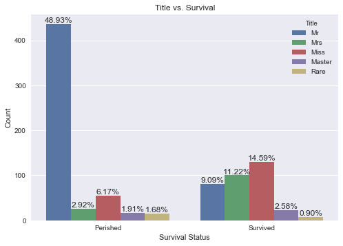

```python
ax = sns.countplot(x='Survived', hue='Title', data=titanic)
sns.despine()

# You can specify a rotation for the tick labels in degrees or with keywords.

##labels = [item.get_text() for item in ax.get_xticklabels()]
##labels[0] = 'Perished'
##labels[1] = 'Survived'

##ax.set_xticklabels(labels)

ax.set_xlabel('Survival Status')
ax.set_ylabel('Count')

total = float(len(titanic))

for p in ax.patches:
    height = p.get_height()
    ax.text(p.get_x()+p.get_width()/2.,
            height + 3,
            '{:1.2f}%'.format((height/total)*100),
            ha="center")

plt.title('Title vs. Survival')
sns.plt.show()
```

Looking at plot above, we can see that there definitely is some correlation between who you are (Master - Under 18, Mr. - Adult male over 18, Mrs. - Married woman etc) and if you survived, Among those who did not survive, a lot of them blong to the title 'Mr', it would help understand if they came as a family, in other words, we would love to know if families sink or swim together.

### 1.2 Family Size

Taking a look at the data dictionary, we see there are two columns, SibSp and Parch. SibSp represents the number of siblings/spouses aboard and Parch represents the number of parents/children aboard Let's create a new variable called Fsize that represents the size of the family, using the formula 1 + SibSp + Parch,

To explain the above formula, take one observation, say the first one.

The name of the person is Braund, Mr. Owen Harris, and he has 1 under the SibSp and 0 under the Parch column, so his family size will be himself + SibSp + Parch, which translates to 1 + SibSp + Parch

```python
titanic['Fsize'] = 1 + titanic['SibSp'] + titanic['Parch']

#Let's create a new variable called Fsize that represents the size of the family,
#using the formula 1 + SibSp + Parch, To explain the above formula, take one observation,
#say the first one.

#The name of the person is Braund, Mr. Owen Harris, and he has 1 under the SibSp and 0 under
#the Parch column, so his family size will be himself + SibSp + Parch, which translates
#to 1 + SibSp + Parch
```

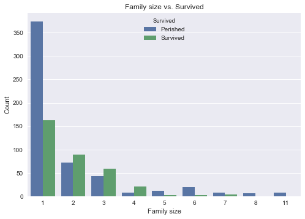

```python
ax = sns.countplot(x='Fsize', hue='Survived', data=titanic)
sns.despine()

ax.axes.set_title('Family size vs. Survived')

ax.set_xlabel('Family size')
ax.set_ylabel('Count')

sns.plt.show()
```

A greater proportion of those who came single (without family members) seem to have died in crash than compared to family sizes 2, 3 and 4.

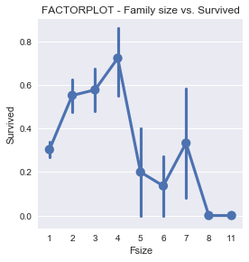

```python
titanic['Survived'].replace(['Perished','Survived'],[0,1],inplace=True)

sns.factorplot(x ='Fsize', y='Survived', data = titanic)
plt.title('FACTORPLOT - Family size vs. Survived')
plt.show()
```

The factor plot helps give a better idea.

```python
titanic['Survived'].replace([0,1],['Perished','Survived'],inplace=True)
```

# 2. Missing Value Imputations

## 2.1. Missing Ages

```python
#A function that is used to calculate the number of missing values and the percentage of
#missing values.

def missing_values_table(titanic):
        mis_val = titanic.isnull().sum()
        mis_val_percent = 100 * titanic.isnull().sum()/len(titanic)
        mis_val_table = pd.concat([mis_val, mis_val_percent], axis=1)
        mis_val_table_ren_columns = mis_val_table.rename(
        columns = {0 : 'Missing Values', 1 : '% of Total Values'})
        return mis_val_table_ren_columns

missing_value_percentage = missing_values_table(titanic)

missing_value_percentage = missing_value_percentage.sort_values('% of Total Values',
                                                                ascending=False)

print(missing_value_percentage)
```

```
             Missing Values  % of Total Values
Cabin                   687          77.104377
Age                     177          19.865320
Embarked                  2           0.224467
PassengerId               0           0.000000
Survived                  0           0.000000
Pclass                    0           0.000000
Name                      0           0.000000
Sex                       0           0.000000
SibSp                     0           0.000000
Parch                     0           0.000000
Ticket                    0           0.000000
Fare                      0           0.000000
Title                     0           0.000000
Fsize                     0           0.000000
```

The output shows the number of missing values in each column. There seems to be 687 missing values in the 'Cabin' column, 177 missing values in the 'Age' column, and 2 missing values in the 'Embarked' column. We will be dropping the 'Cabin' column, since it just has very high percentage of missing values. We will fill the missing values in the 'Age' and 'Embarked' columns.

```python
titanic['Age'].describe()
titanic.columns
```

```
Index([u'PassengerId', u'Survived', u'Pclass', u'Name', u'Sex', u'Age',
       u'SibSp', u'Parch', u'Ticket', u'Fare', u'Cabin', u'Embarked', u'Title',
       u'Fsize'],
      dtype='object')
```

```python
grouped = titanic.groupby(['Title'])[['Age']]
grouped.agg([np.median])
```

| Title | Age median |
| --- | --- |
| Master | 3.5 |
| Miss | 21.0 |
| Mr | 30.0 |
| Mrs | 35.0 |
| Rare | 48.5 |

```python
titagedes = pd.DataFrame(titanic[['PassengerId', 'Survived', 'Pclass', 'Name', 'Sex', 'Age',
       'SibSp', 'Parch', 'Ticket', 'Fare', 'Cabin', 'Embarked', 'Title',
       'Fsize']].copy())

titagedes.Age = titanic.Age.fillna(-1)
```

```python
titagedes['Missing'] = np.where(titagedes['Age']==-1, 'YES', 'NO')
```

```python
titagedes.groupby(['Missing', 'Title']).size()
```

```
Missing  Title
NO       Master     36
         Miss      149
         Mr        398
         Mrs       109
         Rare       22
YES      Master      4
         Miss       36
         Mr        119
         Mrs        17
         Rare        1
dtype: int64
```

We can now understand that, among those age values that are missing, ages of 4 children are missing (children, because of the title 'Master'), ages of 36 unmarried women are missing, (unmarried, because of the title 'Miss'), ages of 119 male adults are missing (male adults above the age of 18, giving are given the title 'Mr'), ages of 17 married women are missing (married, because of the title 'Mrs') and there is one observation with a 'Rare' title (refer to the markdowns previous to this one to understand the different 'Rare' titles)

Lots of complex imputations can be used to fill the missing value of the ages, for the sake of this project, we will find the median age in each title, and replace the missing values using the median ages.

```python
#old
#titanic.loc[(titanic['Title'] == 'Master') & (titanic['Age'] == -1), 'Age'] = 3.5
#titanic.loc[(titanic['Title'] == 'Mr') & (titanic['Age'] == -1), 'Age'] = 30
#titanic.loc[(titanic['Title'] == 'Miss') & (titanic['Age'] == -1), 'Age'] = 21
#titanic.loc[(titanic['Title'] == 'Mrs') & (titanic['Age'] == -1), 'Age'] = 35
#titanic.loc[(titanic['Title'] == 'Rare') & (titanic['Age'] == -1), 'Age'] = 48.5

#new
titanic.groupby('Title').Age.transform('median')
titanic['Age'] = titanic.Age.fillna(titanic.groupby('Title').Age.transform('median'))
```

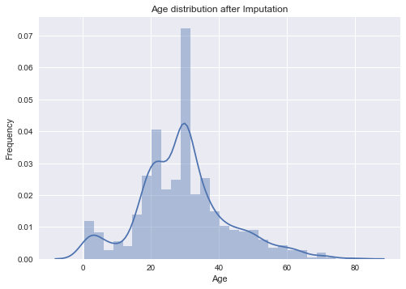

```python
ax = sns.distplot(titanic.Age)
sns.despine()
ax.axes.set_title('Age distribution after Imputation')

ax.set_xlabel('Age')
ax.set_ylabel('Frequency')

sns.plt.show()
```

[figure not shown]

```python
ax = sns.distplot(titanic_bf_imputation.Age)
sns.despine()

ax.axes.set_title('Age distribution after Imputation')
ax.set_xlabel('Age')
ax.set_ylabel('Frequency')

sns.plt.show()
```

The two distribution plots simply show the frequencies in Ages that are present on the datasets before Missing Age imputation and after Missing Age imputation.

## 2.2 Missing Embarked Ports

```python
titanic[titanic['Embarked'].isnull()]

titanic['Embarked'].replace(['C','Q', 'S'],['Cherbourg','Queenstown','Southampton'],inplace=True)

#This string replacement makes it easier for graph axis interpretation
```

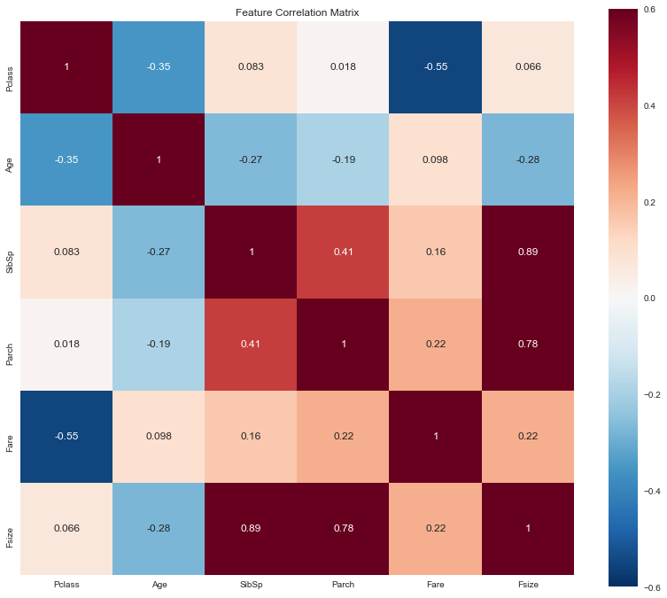

```python
plt.figure(figsize=(14,12))
t = sns.heatmap(titanic.drop('PassengerId',axis=1).corr(), vmax=0.6, square=True, annot=True)
plt.title('Feature Correlation Matrix')
plt.show()
```

It is seen that there is some correlation between 'Pclass' and 'Fare', we can use this to maybe check the relationship with Embarked port too.

Let's now figure out in which of the three locations of Embarkment has there been a median fare of 80$ for the first class.

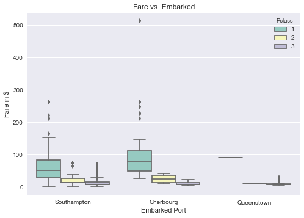

```python
ax = sns.boxplot(x = "Embarked", y = "Fare", hue="Pclass", data=titanic, palette="Set3")

sns.despine()
ax.axes.set_title('Fare vs. Embarked')

ax.set_xlabel('Embarked Port')
ax.set_ylabel('Fare in $')

sns.plt.show()
```

Take a look at the boxplot above. For the Embarked port named 'Cherbourg' observe the First Class which is shaded in greenish-blue color. We see the median line marking around 80. To be exact, let's run a code to find the exact median value of Fare for those who embarked in port 'Cherbourg' and bought the first class ticket.

```python
titanic.groupby(['Embarked', 'Pclass'])['Fare'].median()
```

```
Embarked     Pclass
Cherbourg    1         78.2667
             2         24.0000
             3          7.8958
Queenstown   1         90.0000
             2         12.3500
             3          7.7500
Southampton  1         52.0000
             2         13.5000
             3          8.0500
Name: Fare, dtype: float64
```

It turns out that the median Fare for those who bought a first class ticket who embarked form port 'Cherbourg' is 78.2, which is ~80. So we will fill the two missing values of the embarked column with port ''Cherbourg'.

```python
titanic.loc[titanic['Embarked'].isnull(),'Embarked'] = 'Cherbourg'

titanic.info()
```

```
<class 'pandas.core.frame.DataFrame'>
RangeIndex: 891 entries, 0 to 890
Data columns (total 14 columns):
PassengerId    891 non-null int64
Survived       891 non-null object
Pclass         891 non-null int64
Name           891 non-null object
Sex            891 non-null object
Age            891 non-null float64
SibSp          891 non-null int64
Parch          891 non-null int64
Ticket         891 non-null object
Fare           891 non-null float64
Cabin          204 non-null object
Embarked       891 non-null object
Title          891 non-null object
Fsize          891 non-null int64
dtypes: float64(2), int64(5), object(7)
memory usage: 97.5+ KB
```

# 3. Exploratory Data Analysis

## 3.1. Pclass vs. Survived

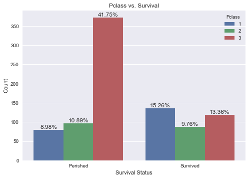

```python
ax = sns.countplot(x='Survived', hue='Pclass', data=titanic)
sns.despine()

labels = [item.get_text() for item in ax.get_xticklabels()]
labels[0] = 'Perished'
labels[1] = 'Survived'

ax.set_xticklabels(labels)
ax.axes.set_title('Pclass vs. Survival')

total = float(len(titanic))

for p in ax.patches:
    height = p.get_height()
    ax.text(p.get_x()+p.get_width()/2.,
            height + 3,
            '{:1.2f}%'.format((height/total)*100),
            ha="center")

ax.set_xlabel('Survival Status')
ax.set_ylabel('Count')

sns.plt.show()
```

From the above graph, among those who did not survive, a lot of them belonged to the 3rd class.

## 3.2. Age vs. Survived

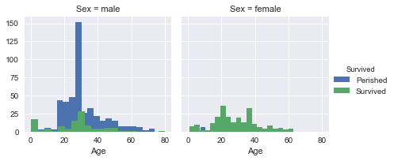

```python
g = sns.FacetGrid(titanic, col='Sex', hue='Survived')
g.map(plt.hist, 'Age', bins=20).add_legend()


plt.show()
```

It is hard to infer from this graph if Age was an important factor that led to Survival. We will later on use a Machine Learning algorithm to figure out the most important features that contributed to Survival.

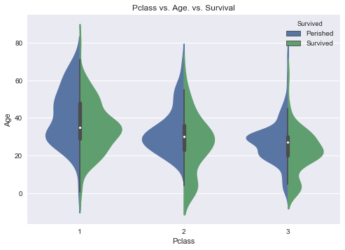

```python
sns.violinplot(x="Pclass", y="Age", hue="Survived", data=titanic, split=True)

plt.title('Pclass vs. Age. vs. Survival')
plt.show()
```

This violin plot does a much better job at helping us visualize Age vs. Survival factored in with the Pclass in which the sample belonged to.

```python
## 3.3. Embarked Port vs. Survived
```

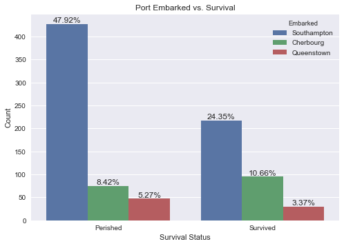

```python
ax = sns.countplot(x='Survived', hue='Embarked', data=titanic)
sns.despine()

plt.title('Port Embarked vs. Survival')

labels = [item.get_text() for item in ax.get_xticklabels()]
labels[0] = 'Perished'
labels[1] = 'Survived'

ax.set_xticklabels(labels)


total = float(len(titanic))

for p in ax.patches:
    height = p.get_height()
    ax.text(p.get_x()+p.get_width()/2.,
            height + 3,
            '{:1.2f}%'.format((height/total)*100),
            ha="center")

ax.set_xlabel('Survival Status')
ax.set_ylabel('Count')

sns.plt.show()
```

```python
titanic['Survived'].replace(['Perished','Survived'],[0,1],inplace=True)
```

# 4. Data Preparation for Modeling.

```python
titanic = titanic.apply(pd.to_numeric, errors='ignore')
#scikitlearn cannot work with categorical variables. So we convert them all the numeric
```

```python
X = pd.DataFrame(titanic[[u'Survived', u'Pclass', u'Sex', u'Age',
       u'SibSp', u'Parch', u'Fare', u'Embarked', u'Title',
       u'Fsize']].copy())

y = pd.DataFrame(X.pop('Survived'))


#X will contain all the features, while y will contain the label alone, in this case 'Survived'.


#old
##for variable in catcol:

##    dummies = pd.get_dummies(X[variable], prefix = variable)
##    X = pd.concat([X,dummies], axis=1)
##    X.drop([variable], axis=1, inplace=True)

#new
catcol = ['Sex', 'Title', 'Embarked']
X = pd.get_dummies(data = X, columns = catcol)
```

```python
X.info()
y.info()
```

```
<class 'pandas.core.frame.DataFrame'>
RangeIndex: 891 entries, 0 to 890
Data columns (total 16 columns):
Pclass                  891 non-null int64
Age                     891 non-null float64
SibSp                   891 non-null int64
Parch                   891 non-null int64
Fare                    891 non-null float64
Fsize                   891 non-null int64
Sex_female              891 non-null uint8
Sex_male                891 non-null uint8
Title_Master            891 non-null uint8
Title_Miss              891 non-null uint8
Title_Mr                891 non-null uint8
Title_Mrs               891 non-null uint8
Title_Rare              891 non-null uint8
Embarked_Cherbourg      891 non-null uint8
Embarked_Queenstown     891 non-null uint8
Embarked_Southampton    891 non-null uint8
dtypes: float64(2), int64(4), uint8(10)
memory usage: 50.5 KB
<class 'pandas.core.frame.DataFrame'>
RangeIndex: 891 entries, 0 to 890
Data columns (total 1 columns):
Survived    891 non-null int64
dtypes: int64(1)
memory usage: 7.0 KB
```

```python
model = RandomForestRegressor(1000, oob_score = True, n_jobs=-1, max_features="auto",
                              random_state=42, min_samples_leaf=5)
model.fit(X,y)
```

```
RandomForestRegressor(bootstrap=True, criterion='mse', max_depth=None,
           max_features='auto', max_leaf_nodes=None,
           min_impurity_split=1e-07, min_samples_leaf=5,
           min_samples_split=2, min_weight_fraction_leaf=0.0,
           n_estimators=1000, n_jobs=-1, oob_score=True, random_state=42,
           verbose=0, warm_start=False)
```

```python
print "C-STAT", roc_auc_score(y, model.oob_prediction_)
```

```
C-STAT 0.878188945345
```

The value for C-STAT shows that the model is pretty decent.

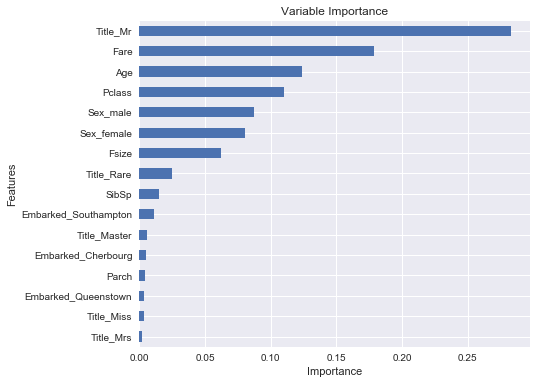

```python
model.feature_importances_

feature_importances = pd.Series(model.feature_importances_, index=X.columns)
feature_importances = feature_importances.sort_values(ascending=True)
ax = feature_importances.plot(kind ="barh", figsize=(7,6));

ax.set_xlabel('Importance')
ax.set_ylabel('Features')
plt.title('Variable Importance')
plt.show()
```

This shows the different variable importances, however, we see that all the dummy encoded variables such as Title and Sex are displayed as seperate categories.

```python
def graph_feature_importances(model, feature_names, autoscale=True,
                              headroom=0.05, width=10, summarized_columns=None):

    if autoscale:
        x_scale = model.feature_importances_.max()+ headroom
    else:
        x_scale=1

    feature_dict=dict(zip(feature_names, model.feature_importances_))

    if summarized_columns:

        for col_name in summarized_columns:

            sum_value = sum(x for i, x in feature_dict.iteritems() if col_name in i)

            keys_to_remove = [i for i in feature_dict.keys() if col_name in i]
            for i in keys_to_remove:
                feature_dict.pop(i)

            feature_dict[col_name] = sum_value

    results = pd.Series(feature_dict.values(), index=feature_dict.keys())

    results = results.sort_values(ascending=True)

    ax = results.plot(kind="barh", figsize=(width,len(results)/4), xlim=(0,x_scale))
    ax.set_xlabel('Importance')
    ax.set_ylabel('Features')
    plt.title('Variable Importance')

graph_feature_importances(model, X.columns, summarized_columns=catcol)

#This is a function that combines the dummy encoded variables and fetches the combined
#importance based on the model we have used to fit it with.
#This function was written by Mike Bernico.
```

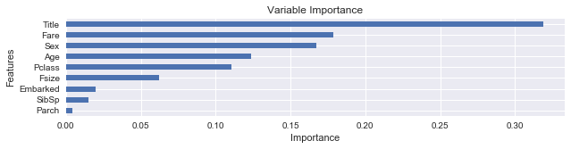

```python
plt.show()
```

The variable importance ranking as per RandomForestRegressor is

1. Title
2. Fare
3. Sex
4. Age
5. Pclass

```python
titanic['Survived'].replace([0,1],['Perished','Survived'],inplace=True)
```

```python
titanic['Survived'].value_counts()
```

```
Perished    549
Survived    342
Name: Survived, dtype: int64
```

# 5. Limitations

1. 77% of missing values in the 'Cabin' column was obviously something you don't want. Knowing which deck the person was in could be an explanatory variable. For example, the first chatacter from the 'Cabin' column shows the deck. If the person was at a lower deck, maybe he could avail the lifeboat service easier than someone who was in the 'F' deck (topmost) deck, and it was harder for him to avail the lifeboat service.
2. Knowledge of Missing Value Imputation techniques: Knowing which method of imputation would give you the best results. Beginners tend to just fill missing values with mean or medians, but a lot of other advaced packages exist for missing value imputations.
3. Choice of Programming Language: Using R instead of Python would've been more easier for Data Analysis due to the abundance of statistical packages. For examaple, the MICE package for Missing Value Imputation exists in R but not in Python, sure if you're skilled enough, you could read the research paper and write your own function, but beginners like me don't know how to go about it.
4. Not having the entire dataset to perform a more thorough analysis. Only 40% of data was used to perform analysis. Then again, this was originally posted on kaggle.com as a Machine Learning competition so maybe the remaining 60% was for testing the built ML model.

# 6. Summaries and Conclusions

1. No. of deceased: 549, No. of survivors: 342, however, only data of 891 out of 2224 was used for analysis.
2. There could be more explanatory variables that explain the survival status of the individual, maybe if there was a variable which depicted a person's ability to swim. Surely, after the crash, some may have drowed straight away and some being good swimmers managed to scramble into a lifeboat. Also, we are only able to infer family sizes but more in depth analysis can be performed if another variable depicted if a certain member was a part of a certain family. This could have been achieved by indexing each member with a family number or maybe that information is already available in the data and I didn't see it.
3. The original data had 687 missing 'Cabin' details, 177 missing 'Age' details and 2 'Embarked Port' details. The Cabin column was simply dropped due to 77% of them missing, the missing values in 'Age' and the 'Embarked' were imputed.
4. The Machine Learning model used in this assignment (Random Forest) was just one of the many Supervised ML Models there is to make predictions. There are many evaluation metrics. One of them used here was the 'ROC_AUC_SCORE'. There are other metrics such as Precision, Recall and others. By no means does one evaulation metric like the one I used say that this model is reliable.

The 'Ideal' metric score depends on the context of the problem that you are trying to solve. If the emphasis is on making correct predictions (that is, when you predict that something is true, then it is), you want to maximize precision (so, in this case, you don't mind missing some cases where it is true (False Negatives), just that when you say it is true then it is). If the emphasis is on making sure that when something is true that you predict it is, then you want to maximize recall (so, in this case, you don't mind predicting cases that aren't true as true (False Positives), just that you catch all of the cases that are true).

# References

1. Mike Bernico (https://www.kaggle.com/justmike): Function that aggregates importance over the split dummy encoded variables
2. Megan Risdel (https://www.kaggle.com/mrisdal/exploring-survival-on-the-titanic): Regular expression to seperate titles from names
3. Lewis (https://stackoverflow.com/users/1168043/cphlewis): Function that displays the percentages on top of bargraphs
4. Myles Callan: Interpretation of evaluation score metrics.